# 9 Collapse census

For the water point census, each water point will be visited by a group of enumerators. All enumerators will complete up to section 2, and the other sections will be completed by a subset of the enumerators The purpose of this script is to collapse these observations into 1 by checking if they match on key variables. We will flag observations as matches and flag non-matches to print in the HFCs.

```r
packages <-
  c(
    "tidyverse",
    "here",
    "haven",
    "viridis",
    "skimr",
    "janitor",
    "assertthat",
    "scales",
    "leaflet",
    "sf",
    "stringdist"
  )

pacman::p_load(
  packages,
  character.only = TRUE
)
```

## 9.1 Load data

```r
test_obs <-
  c(
    "uuid:2d779cb5-c7e7-4207-8a52-f77aa96d7326",
    "uuid:2f5dbf50-a0de-49e5-a4ae-2a0edd530062",
    "uuid:7273e785-af52-4269-a884-0cbd82f53d79",
    "uuid:045484a0-b3eb-4fa8-bbda-9260601c089d",
    "uuid:adc1d56c-ccd7-467a-8c1b-051b13fc15b5",
    "uuid:c771d79c-3c10-45be-bf94-3483a5c1bb54",
    "uuid:f6b6a654-a356-4884-8e02-743e2a6a472e",
    "uuid:8bf1e4e9-e376-4897-8ff6-507f36376d5f",
    "uuid:87a21ef1-1f91-4ea8-8744-98a03560c6e8"
  )
```

These are cases where one enumerator entered one field incorrectly. In these cases, we will take the mode of the response for each variable.

```r
mismatches_checked <-
  c(
    "2030602007012",
    "2030602007011",
    "2050908035007",
    "2100501004006",
    "2030409076002",
    "2030602007013",
    "2011515073002",
    "2101447374004",
    "2030409076001",
    "2030602007019",
    "2030602007015",
    "2041805024002",
    "2030602007018",
    "2050906028002",
    "2052104020009",
    "2030602007004",
    "2011507019001",
    "2011515073008",
    "2011507019003",
    "2101416144002",
    "2030602007016",
    "2101412111015",
    "2100718156004",
    "2030602007017",
    "2011507019002",
    "1170404009007",
    "1110504004011",
    "1040705006006",
    "1160903004001",
    "1151005002002",
    "1120905002001",
    "2101433260019",
    "2101433260001",
    "2041408045025",
    "2041408045020",
    "2041408045002",
    "2041408045013",
    "2041408045021",
    "2050903013001",
    "2070301001012",
    "1222002006005",
    "1021602004005",
    "1181807006008",
    "2101447374006",
    "1180406003005",
    "1181204003002",
    "2041810063001",
    "2030602007014",
    "2041404018003",
    "2041404018004",
    "2041404018005",
    "1180903005001",
    "2041408045019",
    "2011707039017"
  )
```

These observations have fewer valid entries than other entries for the same WP in the ID vars, and will not be considered for the ID variables section.

```r
missing_id_vars <-
  c(
    "uuid:03e4f216-487a-411d-a64f-52b3d58aeb87",
    "uuid:4cddfe3f-3084-4efe-b5a4-656dd12ace1d",
    "uuid:4f7b9a95-18d2-4f77-9023-1f704c992d3e",
    "uuid:97468e5b-9508-4c36-90fc-5d160bbf3454",

    ## Temporary, fix once Aziz updates the data
    "uuid:4efec896-33a4-4f88-afc4-69e5ce2c0c9a",
    "uuid:3ab447dc-3798-4a74-bf6b-e9e6077eb8a4",
    "uuid:c1fabcfc-d27c-41ec-87bf-b73604f8b76d"
  )
```

### 9.1.1 Distance to other water points

```r
distances <-
  read_rds(
    file.path(
      path_box,
      "Data",
      "WaterPointCensus",
      "DataSets",
      "Constructed",
      "water-point-distances.rds"
    )
  )
```

### 9.1.2 Water point characteristics

```r
wp <-
  read_rds(
    file.path(
      path_box,
      "Data",
      "WaterPointCensus",
      "DataSets",
      "Constructed",
      "wp-census-id.rds"
    )
  ) %>%
  mutate(
    wp_id_c = paste0(village_id, str_sub(wp_id, str_length(wp_id) - 2, str_length(wp_id)))
  ) %>%
  arrange(wp_id_c)

assert_that(
  any(test_obs %in% wp$key) == FALSE
)
```

```
## [1] TRUE
```

### 9.1.3 GPS coordinates

```r
wp_sf <-
  read_rds(
    file.path(
      path_box,
      "Data",
      "WaterPointCensus",
      "DataSets",
      "Spatial",
      "wp-gps-clean.rds"
    )
  ) %>%
  dplyr::filter(
    !(key %in% test_obs)
  ) %>%
  select(key, wp_id)
```

## 9.2 Check observations + unique enumerators by wp_id

We expect that for each `wp_id`, there are n observations corresponding to n unique enumerators, where n > 2.

We use these values in the high frequency check flagging code.

```r
wp <-
  wp %>%
  group_by(wp_id_c) %>%
  mutate(
    n_obs = n(),
    n_enum = n_distinct(enumerator_id)
  ) %>%
  ungroup()
```

```r
wp %>%
  tabyl(n_obs) %>%
  adorn_pct_formatting()
```

```
##  n_obs    n percent
##      1   16    0.3%
##      2    6    0.1%
##      3   12    0.2%
##      4  212    3.4%
##      5 5495   89.4%
##      6  282    4.6%
##      7    7    0.1%
##      8   88    1.4%
##      9   18    0.3%
##     10   10    0.2%
```

### 9.2.1 Check distances between observations

Among water points that are very close, we check that the `wp_id` is the same.

```r
dist_check <-
  wp %>%
  transmute(
    key.x = key,
    wp_id.x = wp_id_c
  ) %>%
  inner_join(
    distances,
    by = "key.x"
  ) %>%
  inner_join(
    wp %>%
      transmute(
        key.y = key,
        wp_id.y = wp_id_c
      ),
    by = "key.y"
  )  %>%
  mutate(
    id_match = (wp_id.x == wp_id.y)
  )

nearest_wp <-
  dist_check %>%
  group_by(key.x) %>%
  dplyr::filter(distance == min(distance)) %>%
  ungroup() %>%
  dplyr::select(
    key = key.x,
    wp_id.y,
    distance
  )
```

We plot the frequency of a `id_match` by distance.

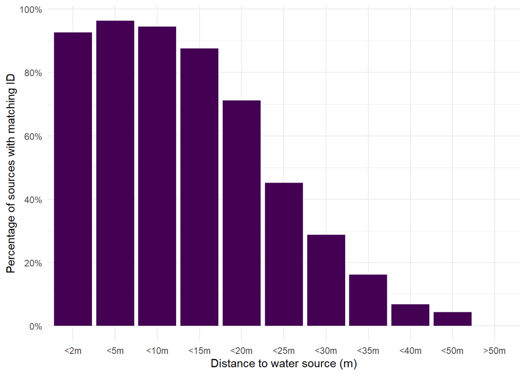

```r
dist_check %>%
  mutate(
    dist_bins =
      case_when(
        distance <= 2 ~ 1,
        distance <= 5 ~ 2,
        distance <= 10 ~ 3,
        distance <= 15 ~ 4,
        distance <= 20 ~ 5,
        distance <= 25 ~ 6,
        distance <= 30 ~ 7,
        distance <= 35 ~ 8,
        distance <= 40 ~ 9,
        distance <= 50 ~ 10,
        TRUE ~ 11
      ) %>%
      factor(
        levels = 1:11,
        labels =
          c(
            "<2m",
            "<5m",
            "<10m",
            "<15m",
            "<20m",
            "<25m",
            "<30m",
            "<35m",
            "<40m",
            "<50m",
            ">50m"
          ),
        ordered = T
      )
  ) %>%
  group_by(dist_bins) %>%
  summarise(
    pct_match = sum(id_match)/n()
  ) %>%
  ungroup() %>%
  ggplot(
    aes(
      x = dist_bins,
      y = pct_match
      )
  ) +
  geom_col(fill = viridis(1)) +
  theme +
  labs(
    x = "Distance to water source (m)",
    y = "Percentage of sources with matching ID"
  ) +
  scale_y_continuous(
    labels = scales::percent,
    breaks = breaks_width(.2)
  )
```

### 9.2.2 Establish criteria for a distance match + water point ID match

```r
bad_gps <- c(
  # start of enumerator MW27379 in Gravel -- their device was off the entire day
  "uuid:4ae0ce01-2e2b-4bef-93ac-c06e8e2c4954",
  "uuid:a6ebdc51-7a52-4489-adc3-c6ab226803ba",
  "uuid:2748c433-d465-4763-bc78-f912693703cc",
  "uuid:3a9d8479-2849-4984-b1d6-1c9dd63dbaef",
  "uuid:0721e6e4-a599-4334-9485-0bb7580a0e7a",
  "uuid:893c29cf-7620-4b6e-baee-5f1b7617610c",
  "uuid:807cda1b-38a5-4b92-aff1-db510f7551c9",
  "uuid:e6ef709f-f2a6-422f-b830-a9ea74a47d20",
  # end of enumerator MW27379 in Gravel

  # start of enumerator MW22121 in Malunga -- their device was off the entire day
  "uuid:6c1da34e-5d8c-4103-bb35-0c822bebf22c",
  "uuid:c97fce87-4309-469f-a4a0-1d689f2d5fed",
  "uuid:fe2c810a-0e56-4bcc-a21f-d907973ef1e3",
  "uuid:848ecc75-2a60-4163-b045-93685dd17703",
  "uuid:53cea14e-7a8a-4810-87e8-207b829e3586",
  "uuid:db14a48c-12d3-45af-8709-8d76a9f3ef76",
  # end of enumerator MW22121 in Malunga

  # MW20384 in Nkalo, WP2030602007006
  "uuid:6f7c22ba-708a-440d-951b-e39be34fb91a",

  # MW22659 in Mtambo, WP2100718156003
  "uuid:dd7925f2-d396-443b-be52-f16e64c30bd2",
  # MW22659 in Mtambo, WP2100718156004
  "uuid:860f71e9-2c2a-47ed-99ed-545d09556e3b",

  # MW26198 in Malowa
  "uuid:052db89b-a570-4f24-a560-8ebe366c8e7b",
  "uuid:2e7970d5-75b8-4d7b-9eac-9c2b8152b8ed",
  "uuid:45b95abd-319e-4c64-89e3-c5109523588d",
  "uuid:e13aa959-6bb0-4ef8-b9e2-f450f8c00970",
  "uuid:d1d627eb-7b93-4624-abf0-cb8d465892ee",
  "uuid:a8c28013-9251-4b36-a8d0-21849ed3558d",
  "uuid:d9361f17-0608-4029-990e-2ebbc9d4ee2c",
  "uuid:33951c56-3e1c-4584-a523-b8f536344bfc",
  "uuid:750f4011-9c7d-4bf2-b22c-8b5fe817b19e",

  # MW26198 in Chipengule
   "uuid:b33d52d0-c1fe-447f-9526-09d16a401dbe",

  # MW22483 in Ojesi
  "uuid:9994e29c-29d4-490b-b8e9-9ca61f579367",

  # 225517 in Kasozi, WP7016008
  "uuid:ce9e87aa-bc36-4157-8060-91a2718f5dcb",

  # 313765 in Buyondo, WP6002015
  "uuid:291bfa86-74bf-45c4-8168-57af53ff9964",

  # 118182 in Amon Gogonyo, WP3002001
  "uuid:9f410ddf-c7bb-42e5-a3ab-56ff058c4af4",

  # MW21532 in Jameskanono, WP2030413107004
  "uuid:6086fce5-e1e9-456f-82f5-87db766253fd",

  # MW25398 in Wilson, WP2020314063002
  "uuid:5879557a-a58f-4f4b-939e-fdd336564256",

  # The program information on this entry is wrong
  "uuid:bfb40401-a5cb-4e9e-8644-6ca56d4f7fa8"
)
```

```r
dist_check <-
  dist_check %>%
  mutate(
    close = (distance <= 25),
    close_id = id_match & close
  )
```

```r
dist_check %>%
  tabyl(close_id) %>%
  adorn_pct_formatting()
```

```
##  close_id       n percent
##     FALSE 2606986   99.1%
##      TRUE   23634    0.9%
```

## 9.3 Check variables match by wp_id

Among sources that are within 25 meters of each other + have the same wp_id, we check that they agree on the following variables: - Location: - country - district_id - village_id - Water source characteristics: - wp_drink - wp_multicompound - wp_name - sourcetype - sourcetype_simp - wp_dsw - wp_ilc - wp_ilc_device - wp_func

*TODO: this should change if new variables are added to sections 2* We compute the percentage of variables that they agree on.

For `wp_name`, enumerators can input a string, so we compute the average string distance between water sources. We consider a `wp_name` to be a match if the average string distance is <= 0.3. I decided on this threshold by trying to compute the string distance between strings with small mispellings.

```r
comparison_vars <-
  c(
    "country",
    "district_id",
    "village_id",
    "wp_name",
    "wp_drink",
    "wp_multicompound",
    "sourcetype",
    "sourcetype_simp",
    "wp_dsw",
    "wp_ilc",
    "wp_ilc_device",
    "wp_func"
  )
```

```r
compare_wps <-
  dist_check %>%
  # select sources within 25m + id match
  dplyr::filter(close_id) %>%
  transmute(
    key = key.x,
    wp_id_c = wp_id.x
  ) %>%
  distinct() %>%
  # Join information from each enumerator
  group_by(wp_id_c) %>%
  mutate(mch_id = cur_group_id()) %>%
  ungroup() %>%
  inner_join(
    wp,
    by = c("key", "wp_id_c")
  ) %>%
  group_by(mch_id) %>%
   mutate(
     # For categorical variables, we can do a binary check
    across(
      all_of(comparison_vars[-c(1)]),
      ~ n_distinct(.) == 1,
      .names = "match_{.col}"
    ),
    # For water source name, we calculate the average string distance
    avg_st_dist = {
      names <- wp_name
        dists <- stringdistmatrix(names, names, method = "jw")
        upper_tri <- dists[upper.tri(dists)]
        mean(upper_tri, na.rm = T)
    },
    match_wp_name = ifelse(is.na(avg_st_dist), F, (avg_st_dist <= 0.3))
  ) %>%
  rowwise() %>%
  mutate(
    pct_match = (sum(
      c_across(
        starts_with("match_")
      ),
      na.rm = TRUE
    )/length(comparison_vars)) * 100
  ) %>%
  ungroup
```

Check if most water points have consistent information

[output not shown]

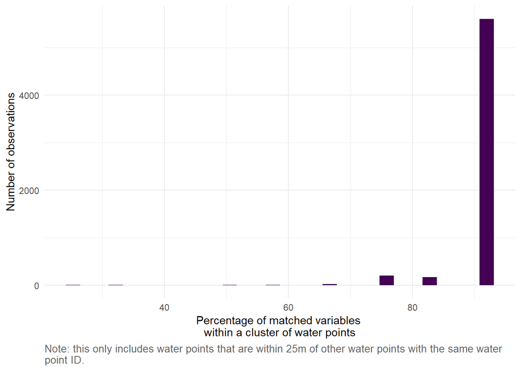

```r
compare_wps %>%
  ggplot() +
  geom_histogram(
    aes(
      x = pct_match
    ),
    fill = viridis(1)
  ) +
  theme +
  labs(
    x = "Percentage of matched variables \nwithin a cluster of water points",
    y = "Number of observations",
    caption =
      paste0(
        "Note: this only includes water points that are within 25m of other",
        " water points with the same water point ID."
      ) %>% str_wrap(100)
  )
```

There are 5 enumerators per team, if only one has a different answer, we will consider it to be the same water point. That means 80% or more of matched variables.

```r
matched <-
  compare_wps %>%
  dplyr::filter(pct_match >= 80) %>%
  pull(key) %>%
  unique()
```

Cases with less than 80% matches are individually inspected:

```r
compare_wps %>%
  dplyr::filter(pct_match < 80) %>%
  tabyl(date)
```

```
##        date  n percent
##  2025-07-07  5   0.020
##  2025-07-15  5   0.020
##  2025-07-16  5   0.020
##  2025-07-17  4   0.016
##  2025-07-18  7   0.028
##  2025-07-19  5   0.020
##  2025-07-20  1   0.004
##  2025-07-21  5   0.020
##  2025-07-22 19   0.076
##  2025-07-23 55   0.220
##  2025-07-26 12   0.048
##  2025-07-27  2   0.008
##  2025-07-28 25   0.100
##  2025-07-29 15   0.060
##  2025-07-30  5   0.020
##  2025-07-31  5   0.020
##  2025-08-04 15   0.060
##  2025-08-05  9   0.036
##  2025-08-06 10   0.040
##  2025-08-07  5   0.020
##  2025-08-09 15   0.060
##  2025-08-11  5   0.020
##  2025-08-14 15   0.060
##  2025-08-16  1   0.004
```

```r
compare_wps %>%
  dplyr::filter(
    !(key %in% matched),
    !(wp_id_c %in% mismatches_checked)
  ) %>%
  arrange(date, wp_id) %>%
  select(key, pct_match, date, country, wp_id, wp_id_c, village_id, enumerator_id, all_of(comparison_vars), wp_photo, comments) %>%
  view
```

```r
good_keys <-
  compare_wps %>%
  dplyr::filter(
    (key %in% matched) | wp_id_c %in% mismatches_checked
  ) %>%
  pull(key) %>%
  unique()
```

### 9.3.1 Check variables that don’t match

For these variables, we check the percentage of observations that don’t match — finding where enumerators tend to make mistakes.

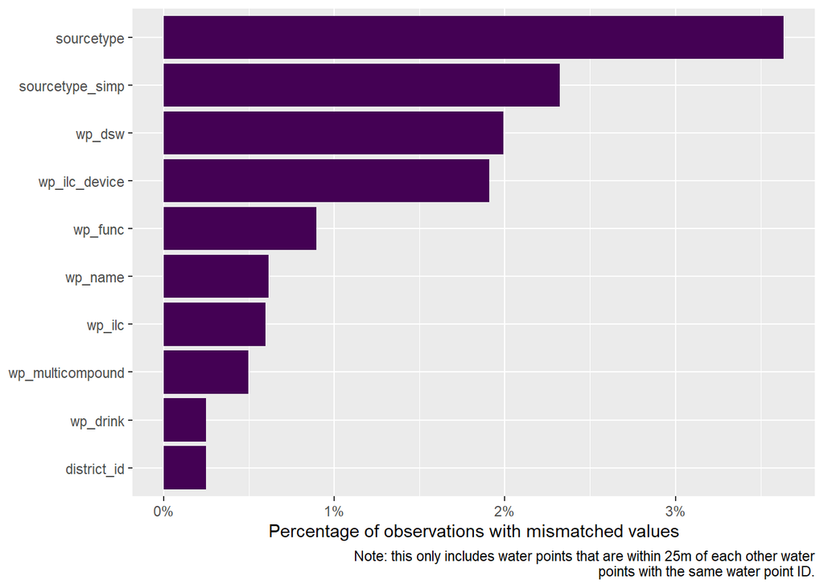

```r
compare_wps %>%
  select(key, starts_with("match_")) %>%
  summarise(
    across(
      starts_with("match"),
      ~ sum(!.x)/n() %>% na_if(0)
    )
  ) %>%
  pivot_longer(
    cols = everything(),
    names_to = "variable",
    values_to = "pct",
    names_prefix = "match_"
  ) %>%
  dplyr::filter(pct > 0) %>%
  ggplot(
    aes(
      x = reorder(variable, pct),
      y = pct
    )
  ) +
  geom_col(fill = viridis(1)) +
  #theme +
  labs(
    x = NULL,
    y = "Percentage of observations with mismatched values",
    caption =
      paste0(
        "Note: this only includes water points that are within 25m of each other",
        " water points with the same water point ID."
      ) %>% str_wrap(80)
  ) +
  scale_y_continuous(labels = scales::percent) +
  coord_flip()
```

### 9.3.2 Water point identification variables

For these variables, we assume the most commonly entered value across all five enumerators who completed the survey is the correct response.

```r
wp_chars <-
  wp %>%
  # Drop observations we know are problematic
  dplyr::filter(key %in% good_keys) %>%
  # Count how many observations have each combination of variables
  group_by(
    wp_id_c,
    across(all_of(comparison_vars))
  ) %>%
  mutate(n = n()) %>%
  # Coalesce variables that may be missing but can be filled with values from other obs
  group_by(wp_id_c) %>%
  mutate(
    district_id = max(district_id, na.rm = TRUE)
  ) %>%
  # Keep only the most common values
  dplyr::filter(n == max(n)) %>%
  group_by(
    country, district_id, village_id,
    wp_id,
    n_obs,
    n_enum,
    wp_drink, wp_multicompound,
    wp_func,
    sourcetype, sourcetype_o, sourcetype_simp,
    wp_dsw, wp_ilc_device, wp_ilc
  ) %>%
  # If all five observations have the same values, select on "randomly"
  dplyr::filter(key == max(key)) %>%
  ungroup %>%
  # These observations have more missing values than others for the same WP, but no conflicting information otherwise
  dplyr::filter(
    !(key %in% missing_id_vars),
    !(wp_id_c == 2070302012011 & wp_id == "WP2070301002011")
  )
```

```r
assert_that(
  nrow(wp_chars) == n_distinct(wp_chars$wp_id_c)
)
```

```
## [1] TRUE
```

```r
wp_chars %>%
  group_by(wp_id_c) %>%
  dplyr::filter(n() > 1) %>%
  view
```

## 9.4 Combine with sections submitted by a single enumerator

### 9.4.1 Spotchecks

```r
spotcheck <-
  read_rds(
    file.path(
      path_box,
      "Data",
      "WaterPointCensus",
      "DataSets",
      "Constructed",
      "wp-census-spotcheck.rds"
    )
  ) %>%
  # There is only one observation for this water point, since the field team went back to collect information based on the GPS from EvAc
  dplyr::filter(wp_id != "WP2011707039017")
```

```r
wp_collapsed <-
  wp_chars %>%
  left_join(
    spotcheck,
    relationship = "one-to-one",
    unmatched = "error"
  )
```

```
## join_by(wp_id)`
```

### 9.4.2 Water testing

```r
tests <-
  read_rds(
    file.path(
      path_box,
      "Data",
      "WaterPointCensus",
      "DataSets",
      "Constructed",
      "wp-constructed-tests.rds"
    )
  )
```

```r
wp_collapsed <-
  wp_collapsed %>%
  left_join(
    tests,
    relationship = "one-to-one",
    unmatched = "error"
  )
```

```
## join_by(wp_id)`
```

```r
assert_that(
  nrow(wp_collapsed) == n_distinct(wp_collapsed$wp_id_c)
)
```

```
## [1] TRUE
```

### 9.4.3 Flag entries that cannot be collapsed

We define the following flags.

If each water source is an ID + distance match with at least 1 water source, this doesn’t work.

```r
flag <-
  dist_check %>%
  group_by(key.x) %>%
  dplyr::filter(max(close_id) == 0) %>%
  mutate(
    dist_flag = as.numeric(close & !id_match),
    wp_id_flag = as.numeric(!close & id_match),
  ) %>%
  dplyr::select(
    key = key.x,
    wp_id = wp_id.x,
    ends_with("flag")
  ) %>%
  group_by(key, wp_id) %>%
  summarise(
    across(
      everything(),
      ~ max(.x, na.rm = T)
    )
  ) %>%
  ungroup() %>%
  mutate(collapse_flag = 1) %>%
  rename(problem_key = key)

wp_flags <-
  flag %>%
  group_by(wp_id) %>%
  summarise(
    dist_flag = max(dist_flag),
    wp_id_flag = max(wp_id_flag),
    collapse_flag = max(collapse_flag),
    .groups="drop"
  )
```

Check that the flag data is at entry_level of observation.

```r
assert_that(
  nrow(flag) == n_distinct(flag$problem_key)
)
```

```
## [1] TRUE
```

```r
wp_collapsed <-
  wp_collapsed %>%
  # merge with collapsed ids
  left_join(wp_flags, by = c("wp_id")) %>%
  # turn missing flags into zeros
  mutate(
    across(
      ends_with("_flag"),
      ~ tidyr::replace_na(.x, 0)
    )
  )
```

### 9.4.4 Add geospatial data

```r
wp_gps <-
  wp_sf %>%
  left_join(wp_collapsed) %>%
  # Remove obs that have incorrect distances
  dplyr::filter(!(key %in% (flag %>% dplyr::filter(dist_flag == 1) %>% pull(problem_key)))) %>%
  # Calculate centroid of different coordinates for the same WP
  group_by(wp_id_c) %>%
  summarise(geometry = st_union(geometry)) %>%
  st_centroid() %>%
  # Join tabular data
  inner_join(wp_collapsed)
```

```
## join_by(key, wp_id)`
## join_by(wp_id_c)`
```

## 9.5 Save

### 9.5.1 Tabular data

```r
path <-
  file.path(
    "Data",
    "WaterPointCensus",
    "DataSets",
    "Constructed",
    "wp-collapsed"
  )

wp_collapsed %>%
  ungroup %>%
  write_meta(
    path_data = file.path(path_box, path),
    path_meta = file.path(path_git, path)
  )
```

Table 9.1: Data summary

| Name | Piped data |
| --- | --- |
| Number of rows | 1217 |
| Number of columns | 211 |
| _______________________ |  |
| Column type frequency: |  |
| character | 76 |
| Date | 2 |
| factor | 15 |
| logical | 50 |
| numeric | 61 |
| POSIXct | 7 |
| ________________________ |  |
| Group variables | None |

**Variable type: character**

| skim_variable | n_missing | complete_rate | min | max | empty | n_unique | whitespace |
| --- | --- | --- | --- | --- | --- | --- | --- |
| key | 0 | 1.00 | 41 | 41 | 0 | 1217 | 0 |
| wp_id | 0 | 1.00 | 9 | 15 | 0 | 1217 | 0 |
| district_id | 0 | 1.00 | 3 | 3 | 0 | 28 | 0 |
| village_id | 0 | 1.00 | 10 | 10 | 0 | 165 | 0 |
| enumerator_id | 0 | 1.00 | 4 | 8 | 0 | 135 | 0 |
| wp_name | 0 | 1.00 | 4 | 57 | 0 | 1192 | 0 |
| wp_photo | 25 | 0.98 | 17 | 17 | 0 | 1192 | 0 |
| wp_use_howmuch | 23 | 0.98 | 4 | 15 | 0 | 4 | 0 |
| dsw_use_howmuch | 827 | 0.32 | 4 | 15 | 0 | 4 | 0 |
| enum_comment | 0 | 1.00 | 2 | 550 | 0 | 463 | 0 |
| sourcetype_o | 1212 | 0.00 | 3 | 3 | 0 | 1 | 0 |
| sourcetype_simp | 113 | 0.91 | 5 | 22 | 0 | 7 | 0 |
| wp_id_c | 0 | 1.00 | 13 | 13 | 0 | 1217 | 0 |
| spotcheck_key | 709 | 0.42 | 41 | 41 | 0 | 508 | 0 |
| spotcheck_enum | 709 | 0.42 | 4 | 8 | 0 | 132 | 0 |
| ilc_problems_o | 1205 | 0.01 | 4 | 168 | 0 | 9 | 0 |
| ilc_devicepic | 1102 | 0.09 | 17 | 17 | 0 | 115 | 0 |
| disp_dsw_datephoto | 984 | 0.19 | 17 | 46 | 0 | 233 | 0 |
| disp_photo | 835 | 0.31 | 17 | 17 | 0 | 382 | 0 |
| disp_barcode_photo | 840 | 0.31 | 17 | 46 | 0 | 377 | 0 |
| disp_barcode | 840 | 0.31 | 5 | 7 | 0 | 374 | 0 |
| jc_key | 917 | 0.25 | 41 | 41 | 0 | 300 | 0 |
| jc_enum | 917 | 0.25 | 4 | 8 | 0 | 114 | 0 |
| jc_comments | 917 | 0.25 | 2 | 548 | 0 | 111 | 0 |
| cw_nocl_key | 938 | 0.23 | 41 | 41 | 0 | 279 | 0 |
| cw_nocl_enum | 938 | 0.23 | 4 | 7 | 0 | 104 | 0 |
| discid_nocl | 938 | 0.23 | 5 | 5 | 0 | 103 | 0 |
| tubeid_nocl | 938 | 0.23 | 4 | 4 | 0 | 101 | 0 |
| tubeid_testtube_nocl | 938 | 0.23 | 4 | 4 | 0 | 124 | 0 |
| discfcr_nocl_dpd_photo | 938 | 0.23 | 17 | 17 | 0 | 279 | 0 |
| discfcr_nocl_vial_photo | 938 | 0.23 | 17 | 46 | 0 | 279 | 0 |
| discfcr_nocl_color_o | 1215 | 0.00 | 5 | 5 | 0 | 1 | 0 |
| discfcr_nocl_comments | 1028 | 0.16 | 1 | 145 | 0 | 38 | 0 |
| disctcr_nocl_dpd_photo | 938 | 0.23 | 17 | 46 | 0 | 279 | 0 |
| disctcr_nocl_vial_photo | 938 | 0.23 | 17 | 46 | 0 | 279 | 0 |
| disctcr_nocl_comments | 1031 | 0.15 | 1 | 88 | 0 | 41 | 0 |
| meter_nocl_key | 1003 | 0.18 | 41 | 41 | 0 | 214 | 0 |
| meter_nocl_enum | 1003 | 0.18 | 4 | 7 | 0 | 102 | 0 |
| meterid_un | 1003 | 0.18 | 5 | 5 | 0 | 32 | 0 |
| meterfcr_nocl_vialid | 1003 | 0.18 | 5 | 5 | 0 | 32 | 0 |
| meterfcr_nocl_dpd_photo | 1003 | 0.18 | 17 | 46 | 0 | 214 | 0 |
| meterfcr_nocl_error | 1216 | 0.00 | 4 | 4 | 0 | 1 | 0 |
| meterfcr_nocl_vial_photo | 1004 | 0.18 | 17 | 46 | 0 | 213 | 0 |
| no_meterfcr_nocl_vial_photo | 1216 | 0.00 | 16 | 16 | 0 | 1 | 0 |
| meterfcr_nocl_comments | 1080 | 0.11 | 4 | 84 | 0 | 25 | 0 |
| metertcr_nocl_vialid | 1003 | 0.18 | 5 | 5 | 0 | 31 | 0 |
| metertcr_nocl_dpd_photo | 1004 | 0.18 | 17 | 46 | 0 | 213 | 0 |
| metertcr_nocl_error | 1032 | 0.15 | 23 | 125 | 0 | 185 | 0 |
| metertcr_nocl_comments | 1075 | 0.12 | 4 | 68 | 0 | 36 | 0 |
| cw_key | 851 | 0.30 | 41 | 41 | 0 | 366 | 0 |
| cw_enum | 851 | 0.30 | 4 | 8 | 0 | 126 | 0 |
| tubeid | 898 | 0.26 | 4 | 4 | 0 | 113 | 0 |
| tubeid_testtube | 898 | 0.26 | 4 | 4 | 0 | 137 | 0 |
| discid | 898 | 0.26 | 3 | 6 | 0 | 121 | 0 |
| discfcr_dpd_photo | 898 | 0.26 | 17 | 17 | 0 | 319 | 0 |
| discfcr_vial_photo | 898 | 0.26 | 17 | 17 | 0 | 319 | 0 |
| discfcr_comments | 1014 | 0.17 | 2 | 67 | 0 | 39 | 0 |
| disctcr_dpd_photo | 898 | 0.26 | 17 | 17 | 0 | 319 | 0 |
| disctcr_vial_photo | 898 | 0.26 | 17 | 17 | 0 | 319 | 0 |
| disctcr_comments | 1014 | 0.17 | 2 | 121 | 0 | 43 | 0 |
| jc_wait_str | 970 | 0.20 | 3 | 4 | 0 | 221 | 0 |
| jc_wait_end | 970 | 0.20 | 3 | 4 | 0 | 234 | 0 |
| jc_wait_diff | 970 | 0.20 | 1 | 5 | 0 | 187 | 0 |
| meter_key | 852 | 0.30 | 41 | 41 | 0 | 365 | 0 |
| meter_enum | 852 | 0.30 | 4 | 8 | 0 | 127 | 0 |
| meterfcr_vialid | 897 | 0.26 | 5 | 5 | 0 | 35 | 0 |
| metertcr_vialid | 897 | 0.26 | 5 | 5 | 0 | 36 | 0 |
| meterid | 897 | 0.26 | 5 | 5 | 0 | 38 | 0 |
| meterfcr_dpd_photo | 897 | 0.26 | 17 | 17 | 0 | 320 | 0 |
| meterfcr_vial_photo | 897 | 0.26 | 17 | 17 | 0 | 320 | 0 |
| meterfcr_comments | 1002 | 0.18 | 2 | 55 | 0 | 47 | 0 |
| metertcr_dpd_photo | 897 | 0.26 | 17 | 17 | 0 | 320 | 0 |
| metertcr_error | 1215 | 0.00 | 4 | 4 | 0 | 2 | 0 |
| metertcr_vial_photo | 897 | 0.26 | 17 | 17 | 0 | 320 | 0 |
| metertcr_comments | 1009 | 0.17 | 2 | 298 | 0 | 51 | 0 |
| meter_comments | 852 | 0.30 | 2 | 548 | 0 | 123 | 0 |

**Variable type: Date**

| skim_variable | n_missing | complete_rate | min | max | median | n_unique |
| --- | --- | --- | --- | --- | --- | --- |
| date | 0 | 1.00 | 2025-07-02 | 2025-08-22 | 2025-07-30 | 43 |
| disp_dsw_date | 1023 | 0.16 | 1992-06-15 | 2025-08-01 | 2023-02-14 | 104 |

**Variable type: factor**

| skim_variable | n_missing | complete_rate | ordered | n_unique | top_counts |
| --- | --- | --- | --- | --- | --- |
| country | 0 | 1.00 | FALSE | 2 | Mal: 675, Uga: 542 |
| sourcetype | 113 | 0.91 | FALSE | 12 | Bor: 527, Mun: 232, Pro: 111, Pro: 61 |
| wp_func_last | 1196 | 0.02 | FALSE | 4 | Bet: 8, Les: 7, Bet: 3, Mor: 3 |
| wp_turbidity | 730 | 0.40 | FALSE | 4 | 1: 385, 2: 71, 3: 29, 4: 2 |
| wp_cost_period | 941 | 0.23 | FALSE | 7 | Mon: 127, As : 92, Ann: 42, Qua: 9 |
| disp_dsw_gen | 835 | 0.31 | FALSE | 2 | Gen: 369, Gen: 13, Can: 0, Gen: 0 |
| disp_dose | 969 | 0.20 | TRUE | 3 | 3 m: 204, Les: 27, Mor: 17 |
| discfcr_nocl_color | 938 | 0.23 | FALSE | 3 | 1 -: 268, 2 -: 9, Oth: 2, 3 -: 0 |
| disctcr_nocl_color | 938 | 0.23 | FALSE | 2 | 1 -: 248, 2 -: 31, Oth: 0, 3 -: 0 |
| meterfcr_nocl_color | 1003 | 0.18 | FALSE | 3 | 1 -: 196, 2 -: 17, 4 -: 1, Oth: 0 |
| metertcr_nocl_color | 1003 | 0.18 | FALSE | 2 | 1 -: 184, 2 -: 30, Oth: 0, 3 -: 0 |
| discfcr_color | 898 | 0.26 | FALSE | 4 | 3 -: 160, 2 -: 63, 1 -: 58, 4 -: 38 |
| disctcr_color | 898 | 0.26 | FALSE | 4 | 3 -: 147, 4 -: 76, 2 -: 51, 1 -: 45 |
| meterfcr_color | 897 | 0.26 | FALSE | 4 | 3 -: 128, 4 -: 103, 1 -: 52, 2 -: 37 |
| metertcr_color | 897 | 0.26 | FALSE | 4 | 4 -: 142, 3 -: 102, 1 -: 47, 2 -: 29 |

**Variable type: logical**

| skim_variable | n_missing | complete_rate | mean | count |
| --- | --- | --- | --- | --- |
| wp_drink | 0 | 1.00 | 0.91 | TRU: 1109, FAL: 108 |
| wp_multicompound | 0 | 1.00 | 0.94 | TRU: 1146, FAL: 71 |
| wp_func | 0 | 1.00 | 0.87 | TRU: 1053, FAL: 164 |
| wp_func_c | 0 | 1.00 | 0.87 | TRU: 1056, FAL: 161 |
| wp_promoter | 679 | 0.44 | 0.12 | FAL: 476, TRU: 62 |
| wp_dsw | 265 | 0.78 | 0.41 | FAL: 559, TRU: 393 |
| wp_ilc_device | 115 | 0.91 | 0.13 | FAL: 964, TRU: 138 |
| wp_ilc | 495 | 0.59 | 0.24 | FAL: 547, TRU: 175 |
| spotcheck | 709 | 0.42 | 1.00 | TRU: 508 |
| wp_notfunc_dry | 1212 | 0.00 | 0.20 | FAL: 4, TRU: 1 |
| wp_notfunc_pump | 1212 | 0.00 | 1.00 | TRU: 5 |
| wp_notfunc_ilc_dry | 1205 | 0.01 | 0.75 | TRU: 9, FAL: 3 |
| wp_notfunc_ilc_pump | 1205 | 0.01 | 0.08 | FAL: 11, TRU: 1 |
| wp_notfunc_ilc_pipe | 1205 | 0.01 | 0.17 | FAL: 10, TRU: 2 |
| wp_notfunc_ilc_tank | 1205 | 0.01 | 0.08 | FAL: 11, TRU: 1 |
| wp_notfunc_ilc_closed | 1205 | 0.01 | 0.08 | FAL: 11, TRU: 1 |
| wp_notfunc_ilc_power | 1205 | 0.01 | 0.08 | FAL: 11, TRU: 1 |
| wp_notfunc_ilc_panel | 1205 | 0.01 | 0.25 | FAL: 9, TRU: 3 |
| wp_pay | 731 | 0.40 | 0.57 | TRU: 277, FAL: 209 |
| wp_pay_c | 731 | 0.40 | 0.57 | TRU: 276, FAL: 210 |
| wp_pay_userfees | 941 | 0.23 | 0.08 | FAL: 253, TRU: 23 |
| wp_pay_maintenance | 941 | 0.23 | 0.93 | TRU: 256, FAL: 20 |
| ilc_climb | 1087 | 0.11 | 0.64 | TRU: 83, FAL: 47 |
| ilc_operator | 1087 | 0.11 | 0.50 | FAL: 65, TRU: 65 |
| ilc_tabletholder | 1091 | 0.10 | 0.87 | TRU: 110, FAL: 16 |
| ilc_covercap | 1091 | 0.10 | 0.89 | TRU: 112, FAL: 14 |
| ilc_deviceclamped | 1091 | 0.10 | 0.89 | TRU: 112, FAL: 14 |
| ilc_devicefunc | 1090 | 0.10 | 0.69 | TRU: 87, FAL: 40 |
| ilc_connections | 1092 | 0.10 | 0.07 | FAL: 116, TRU: 9 |
| ilc_problems | 1092 | 0.10 | 0.10 | FAL: 113, TRU: 12 |
| ilc_stock | 1087 | 0.11 | 0.41 | FAL: 77, TRU: 53 |
| disp_tank_present | 835 | 0.31 | 0.97 | TRU: 370, FAL: 12 |
| disp_casing_present | 835 | 0.31 | 1.00 | TRU: 381, FAL: 1 |
| disp_pvc_pole_present | 835 | 0.31 | 1.00 | TRU: 381, FAL: 1 |
| flag_wpcensus_conflict | 1195 | 0.02 | 1.00 | TRU: 22 |
| disp_func | 917 | 0.25 | 1.00 | TRU: 299, FAL: 1 |
| disp_filled | 918 | 0.25 | 0.84 | TRU: 251, FAL: 48 |
| colorwheel_un | 938 | 0.23 | 1.00 | TRU: 279 |
| colorimeter_un | 1003 | 0.18 | 1.00 | TRU: 214 |
| meterfcr_nocl_zero | 1003 | 0.18 | 1.00 | TRU: 214 |
| metertcr_nocl_zero | 1003 | 0.18 | 1.00 | TRU: 214 |
| colorwheel | 851 | 0.30 | 1.00 | TRU: 366 |
| jc_valve | 923 | 0.24 | 1.00 | TRU: 294 |
| jc_chlorine | 923 | 0.24 | 0.84 | TRU: 247, FAL: 47 |
| jc_mllost | 923 | 0.24 | 0.27 | FAL: 215, TRU: 79 |
| colorimeter | 852 | 0.30 | 1.00 | TRU: 365 |
| meterfcr_zero | 897 | 0.26 | 1.00 | TRU: 320 |
| meterfcr_error04 | 1207 | 0.01 | 1.00 | TRU: 10 |
| metertcr_zero | 897 | 0.26 | 1.00 | TRU: 320 |
| metertcr_error04 | 1204 | 0.01 | 1.00 | TRU: 13 |

**Variable type: numeric**

| skim_variable | n_missing | complete_rate | mean | sd | p0 | p25 | p50 | p75 | p100 | hist |
| --- | --- | --- | --- | --- | --- | --- | --- | --- | --- | --- |
| n_obs | 0 | 1.00 | 5.02 | 0.49 | 2.0 | 5.00 | 5.00 | 5.00 | 1.000000e+01 | ▁▇▁▁▁ |
| n_enum | 0 | 1.00 | 5.00 | 0.41 | 2.0 | 5.00 | 5.00 | 5.00 | 8.000000e+00 | ▁▁▇▁▁ |
| n | 0 | 1.00 | 4.61 | 0.73 | 1.0 | 4.00 | 5.00 | 5.00 | 1.000000e+01 | ▁▃▇▁▁ |
| wp_cost | 948 | 0.22 | 1452.79 | 1989.65 | 50.0 | 500.00 | 1000.00 | 1500.00 | 1.500000e+04 | ▇▁▁▁▁ |
| ilc_wcps | 1093 | 0.10 | 17.56 | 89.77 | 1.0 | 1.00 | 3.00 | 19.00 | 1.000000e+03 | ▇▁▁▁▁ |
| ilc_tabletstock | 1164 | 0.04 | 2.98 | 1.72 | 0.0 | 2.00 | 3.00 | 3.00 | 1.000000e+01 | ▆▇▁▁▁ |
| disp_dsw_id | 956 | 0.21 | 138109734.51 | 711901711.17 | 870.0 | 70180587.00 | 80022200.00 | 83050458.00 | 8.204216e+09 | ▇▁▁▁▁ |
| count | 709 | 0.42 | 1.24 | 0.79 | 1.0 | 1.00 | 1.00 | 1.00 | 5.000000e+00 | ▇▁▁▁▁ |
| jc_wait | 965 | 0.21 | 1657.66 | 615.98 | 0.0 | 1806.75 | 1846.00 | 1977.25 | 2.597000e+03 | ▁▁▁▇▂ |
| discfcr_nocl_timestamp0 | 939 | 0.23 | 701.03 | 358.94 | 200.0 | 441.25 | 621.50 | 857.25 | 2.396000e+03 | ▇▆▂▁▁ |
| discfcr_nocl_timestamp1 | 939 | 0.23 | 947.31 | 433.03 | 240.0 | 632.25 | 868.50 | 1162.50 | 2.895000e+03 | ▇▇▂▁▁ |
| discfcr_nocl_timestamp2 | 938 | 0.23 | 1060.68 | 428.39 | 277.0 | 748.00 | 1007.00 | 1284.50 | 3.015000e+03 | ▆▇▂▁▁ |
| discfcr_un | 938 | 0.23 | 0.00 | 0.02 | 0.0 | 0.00 | 0.00 | 0.00 | 2.000000e-01 | ▇▁▁▁▁ |
| discfcr_nocl_confirm_un | 938 | 0.23 | 0.00 | 0.02 | 0.0 | 0.00 | 0.00 | 0.00 | 2.000000e-01 | ▇▁▁▁▁ |
| disctcr_nocl_timestamp0 | 939 | 0.23 | 1159.60 | 459.22 | 307.0 | 823.50 | 1100.00 | 1413.75 | 3.179000e+03 | ▅▇▂▁▁ |
| disctcr_nocl_timestamp1 | 938 | 0.23 | 1278.78 | 494.44 | 322.0 | 927.50 | 1218.00 | 1551.50 | 3.364000e+03 | ▅▇▃▁▁ |
| disctcr_nocl_timestamp2 | 938 | 0.23 | 1520.94 | 504.40 | 349.0 | 1164.50 | 1486.00 | 1795.50 | 3.640000e+03 | ▂▇▅▁▁ |
| disctcr_un | 938 | 0.23 | 0.01 | 0.04 | 0.0 | 0.00 | 0.00 | 0.00 | 2.000000e-01 | ▇▁▁▁▁ |
| disctcr_nocl_confirm_un | 938 | 0.23 | 0.01 | 0.04 | 0.0 | 0.00 | 0.00 | 0.00 | 2.000000e-01 | ▇▁▁▁▁ |
| meterfcr_nocl_timestamp0 | 1003 | 0.18 | 722.39 | 399.62 | 191.0 | 455.25 | 645.00 | 905.75 | 3.718000e+03 | ▇▂▁▁▁ |
| meterfcr_nocl_timestamp1 | 1003 | 0.18 | 900.67 | 426.22 | 240.0 | 596.00 | 821.50 | 1105.50 | 3.735000e+03 | ▇▅▁▁▁ |
| meterfcr_nocl_timestamp3 | 1003 | 0.18 | 1021.50 | 440.12 | 280.0 | 707.00 | 949.00 | 1257.50 | 3.772000e+03 | ▇▆▁▁▁ |
| meterfcr_nocl_timestamp4 | 1003 | 0.18 | 1132.05 | 442.82 | 402.0 | 805.50 | 1078.00 | 1365.75 | 3.894000e+03 | ▇▆▁▁▁ |
| meterfcr_un | 1004 | 0.18 | 0.05 | 0.09 | 0.0 | 0.01 | 0.03 | 0.06 | 7.800000e-01 | ▇▁▁▁▁ |
| meterfcr_nocl_confirm_un | 1004 | 0.18 | 0.05 | 0.09 | 0.0 | 0.01 | 0.03 | 0.06 | 7.800000e-01 | ▇▁▁▁▁ |
| meterfcr_nocl_timestamp5 | 1003 | 0.18 | 1215.73 | 451.82 | 436.0 | 881.00 | 1154.50 | 1467.25 | 3.935000e+03 | ▇▇▁▁▁ |
| meterfcr_nocl_timestamp6 | 1003 | 0.18 | 1243.01 | 459.83 | 447.0 | 901.50 | 1167.50 | 1510.75 | 3.937000e+03 | ▇▇▁▁▁ |
| metertcr_nocl_timestamp0 | 1003 | 0.18 | 1243.01 | 459.83 | 447.0 | 901.50 | 1167.50 | 1510.75 | 3.937000e+03 | ▇▇▁▁▁ |
| metertcr_nocl_timestamp1 | 1003 | 0.18 | 1347.57 | 485.70 | 480.0 | 976.25 | 1319.50 | 1644.75 | 3.966000e+03 | ▇▇▂▁▁ |
| metertcr_nocl_timestamp3 | 1003 | 0.18 | 1433.34 | 508.89 | 503.0 | 1037.75 | 1389.50 | 1703.75 | 4.249000e+03 | ▇▇▂▁▁ |
| metertcr_nocl_timestamp4 | 1003 | 0.18 | 1738.61 | 577.21 | 703.0 | 1317.75 | 1697.00 | 2036.75 | 4.439000e+03 | ▆▇▂▁▁ |
| metertcr_un | 1003 | 0.18 | 0.09 | 0.22 | 0.0 | 0.02 | 0.04 | 0.09 | 2.200000e+00 | ▇▁▁▁▁ |
| metertcr_nocl_confirm_un | 1003 | 0.18 | 0.09 | 0.22 | 0.0 | 0.02 | 0.04 | 0.09 | 2.200000e+00 | ▇▁▁▁▁ |
| metertcr_nocl_timestamp5 | 1003 | 0.18 | 1899.84 | 724.11 | 818.0 | 1416.75 | 1786.50 | 2215.50 | 5.882000e+03 | ▇▆▁▁▁ |
| metertcr_nocl_timestamp6 | 1003 | 0.18 | 1912.97 | 726.15 | 821.0 | 1421.50 | 1793.50 | 2219.00 | 5.885000e+03 | ▇▆▁▁▁ |
| discfcr_timestamp0 | 967 | 0.21 | 2229.80 | 973.08 | 141.0 | 2109.00 | 2533.50 | 2780.25 | 5.470000e+03 | ▃▂▇▁▁ |
| discfcr_timestamp1 | 898 | 0.26 | 2498.85 | 1033.17 | 152.0 | 2209.50 | 2700.00 | 3073.00 | 5.805000e+03 | ▂▂▇▁▁ |
| discfcr_timestamp2 | 898 | 0.26 | 2622.11 | 1042.43 | 400.0 | 2316.00 | 2818.00 | 3239.50 | 5.866000e+03 | ▃▂▇▁▁ |
| discfcr | 898 | 0.26 | 0.63 | 0.52 | 0.0 | 0.20 | 0.60 | 1.00 | 3.200000e+00 | ▇▅▁▁▁ |
| disctcr_timestamp0 | 967 | 0.21 | 2678.21 | 1063.77 | 477.0 | 2440.50 | 2918.00 | 3292.00 | 6.145000e+03 | ▃▃▇▁▁ |
| disctcr_timestamp1 | 898 | 0.26 | 2884.59 | 1103.00 | 519.0 | 2525.00 | 3050.00 | 3508.00 | 6.515000e+03 | ▃▃▇▁▁ |
| disctcr_timestamp2 | 898 | 0.26 | 3139.31 | 1101.40 | 606.0 | 2771.00 | 3293.00 | 3770.00 | 6.722000e+03 | ▂▃▇▂▁ |
| disctcr | 898 | 0.26 | 0.82 | 0.64 | 0.0 | 0.40 | 0.80 | 1.20 | 3.400000e+00 | ▇▆▂▁▁ |
| jc_mldispensed | 970 | 0.20 | 2.96 | 0.48 | 1.2 | 2.95 | 3.00 | 3.00 | 7.300000e+00 | ▁▇▁▁▁ |
| meterfcr_timestamp0 | 966 | 0.21 | 2243.38 | 933.58 | 206.0 | 2088.50 | 2483.00 | 2773.50 | 5.353000e+03 | ▂▂▇▁▁ |
| meterfcr_timestamp1 | 897 | 0.26 | 2446.10 | 1044.83 | 234.0 | 2187.25 | 2602.00 | 2967.75 | 7.330000e+03 | ▃▇▂▁▁ |
| meterfcr_timestamp3 | 897 | 0.26 | 2550.84 | 1054.85 | 257.0 | 2263.25 | 2689.00 | 3071.50 | 7.670000e+03 | ▂▇▂▁▁ |
| meterfcr_timestamp4 | 897 | 0.26 | 2676.98 | 1058.17 | 291.0 | 2396.00 | 2822.50 | 3187.25 | 7.747000e+03 | ▂▇▂▁▁ |
| meterfcr | 897 | 0.26 | 0.88 | 0.70 | 0.0 | 0.23 | 0.83 | 1.34 | 4.600000e+00 | ▇▆▁▁▁ |
| meterfcr_timestamp5 | 898 | 0.26 | 2762.75 | 1073.73 | 342.0 | 2468.50 | 2905.00 | 3296.50 | 7.913000e+03 | ▂▇▃▁▁ |
| meterfcr_timestamp6 | 897 | 0.26 | 2781.98 | 1085.22 | 343.0 | 2467.50 | 2916.00 | 3335.50 | 8.000000e+03 | ▂▇▃▁▁ |
| metertcr_timestamp0 | 966 | 0.21 | 2706.59 | 1017.43 | 343.0 | 2471.50 | 2899.00 | 3242.50 | 5.967000e+03 | ▂▂▇▁▁ |
| metertcr_timestamp1 | 897 | 0.26 | 2877.56 | 1103.18 | 361.0 | 2510.50 | 3011.50 | 3463.75 | 8.160000e+03 | ▂▇▃▁▁ |
| metertcr_timestamp3 | 897 | 0.26 | 2958.88 | 1131.47 | 386.0 | 2552.25 | 3096.50 | 3519.50 | 8.850000e+03 | ▂▇▂▁▁ |
| metertcr_timestamp4 | 897 | 0.26 | 3256.60 | 1157.05 | 784.0 | 2831.75 | 3395.00 | 3837.75 | 9.295000e+03 | ▂▇▁▁▁ |
| metertcr | 899 | 0.26 | 0.96 | 0.73 | 0.0 | 0.38 | 0.93 | 1.43 | 5.100000e+00 | ▇▆▁▁▁ |
| metertcr_timestamp5 | 898 | 0.26 | 3385.28 | 1190.20 | 838.0 | 2891.50 | 3472.00 | 4033.00 | 9.364000e+03 | ▃▇▂▁▁ |
| metertcr_timestamp6 | 897 | 0.26 | 3410.12 | 1200.75 | 839.0 | 2898.75 | 3482.00 | 4072.25 | 9.414000e+03 | ▃▇▂▁▁ |
| dist_flag | 0 | 1.00 | 0.00 | 0.00 | 0.0 | 0.00 | 0.00 | 0.00 | 0.000000e+00 | ▁▁▇▁▁ |
| wp_id_flag | 0 | 1.00 | 0.00 | 0.00 | 0.0 | 0.00 | 0.00 | 0.00 | 0.000000e+00 | ▁▁▇▁▁ |
| collapse_flag | 0 | 1.00 | 0.00 | 0.00 | 0.0 | 0.00 | 0.00 | 0.00 | 0.000000e+00 | ▁▁▇▁▁ |

**Variable type: POSIXct**

| skim_variable | n_missing | complete_rate | min | max | median | n_unique |
| --- | --- | --- | --- | --- | --- | --- |
| submissiondate | 0 | 1.00 | 2025-07-02 18:28:05 | 2025-08-22 17:46:21 | 2025-07-30 18:51:48 | 1210 |
| spotcheck_time | 709 | 0.42 | 2025-07-02 18:28:02 | 2025-08-23 06:32:45 | 2025-07-30 20:33:16 | 506 |
| jc_time | 917 | 0.25 | 2025-07-02 18:29:05 | 2025-08-23 06:32:41 | 2025-07-28 18:29:16 | 299 |
| cw_nocl_time | 938 | 0.23 | 2025-07-21 17:40:30 | 2025-08-22 17:46:10 | 2025-08-01 16:54:57 | 278 |
| meter_nocl_time | 1003 | 0.18 | 2025-07-21 17:44:39 | 2025-08-19 15:22:54 | 2025-07-30 17:54:08 | 213 |
| cw_time | 851 | 0.30 | 2025-07-02 18:29:05 | 2025-08-23 06:32:41 | 2025-07-29 13:56:10 | 366 |
| meter_time | 852 | 0.30 | 2025-07-02 18:30:48 | 2025-08-23 06:32:32 | 2025-07-29 15:28:51 | 365 |

### 9.5.2 Spatial data

```r
path <-
  file.path(
    "Data",
    "WaterPointCensus",
    "DataSets",
    "Spatial",
    "wp-gps-collapsed"
  )

wp_gps %>%
  ungroup %>%
  write_meta(
    path_data = file.path(path_box, path),
    path_meta = file.path(path_git, path)
  )
```

Table 9.2: Data summary

| Name | Piped data |
| --- | --- |
| Number of rows | 1217 |
| Number of columns | 212 |
| _______________________ |  |
| Column type frequency: |  |
| character | 77 |
| Date | 2 |
| factor | 15 |
| logical | 50 |
| numeric | 61 |
| POSIXct | 7 |
| ________________________ |  |
| Group variables | None |

**Variable type: character**

| skim_variable | n_missing | complete_rate | min | max | empty | n_unique | whitespace |
| --- | --- | --- | --- | --- | --- | --- | --- |
| wp_id_c | 0 | 1.00 | 13 | 13 | 0 | 1217 | 0 |
| geometry | 0 | 1.00 | 33 | 38 | 0 | 1217 | 0 |
| key | 0 | 1.00 | 41 | 41 | 0 | 1217 | 0 |
| wp_id | 0 | 1.00 | 9 | 15 | 0 | 1217 | 0 |
| district_id | 0 | 1.00 | 3 | 3 | 0 | 28 | 0 |
| village_id | 0 | 1.00 | 10 | 10 | 0 | 165 | 0 |
| enumerator_id | 0 | 1.00 | 4 | 8 | 0 | 135 | 0 |
| wp_name | 0 | 1.00 | 4 | 57 | 0 | 1192 | 0 |
| wp_photo | 25 | 0.98 | 17 | 17 | 0 | 1192 | 0 |
| wp_use_howmuch | 23 | 0.98 | 4 | 15 | 0 | 4 | 0 |
| dsw_use_howmuch | 827 | 0.32 | 4 | 15 | 0 | 4 | 0 |
| enum_comment | 0 | 1.00 | 2 | 550 | 0 | 463 | 0 |
| sourcetype_o | 1212 | 0.00 | 3 | 3 | 0 | 1 | 0 |
| sourcetype_simp | 113 | 0.91 | 5 | 22 | 0 | 7 | 0 |
| spotcheck_key | 709 | 0.42 | 41 | 41 | 0 | 508 | 0 |
| spotcheck_enum | 709 | 0.42 | 4 | 8 | 0 | 132 | 0 |
| ilc_problems_o | 1205 | 0.01 | 4 | 168 | 0 | 9 | 0 |
| ilc_devicepic | 1102 | 0.09 | 17 | 17 | 0 | 115 | 0 |
| disp_dsw_datephoto | 984 | 0.19 | 17 | 46 | 0 | 233 | 0 |
| disp_photo | 835 | 0.31 | 17 | 17 | 0 | 382 | 0 |
| disp_barcode_photo | 840 | 0.31 | 17 | 46 | 0 | 377 | 0 |
| disp_barcode | 840 | 0.31 | 5 | 7 | 0 | 374 | 0 |
| jc_key | 917 | 0.25 | 41 | 41 | 0 | 300 | 0 |
| jc_enum | 917 | 0.25 | 4 | 8 | 0 | 114 | 0 |
| jc_comments | 917 | 0.25 | 2 | 548 | 0 | 111 | 0 |
| cw_nocl_key | 938 | 0.23 | 41 | 41 | 0 | 279 | 0 |
| cw_nocl_enum | 938 | 0.23 | 4 | 7 | 0 | 104 | 0 |
| discid_nocl | 938 | 0.23 | 5 | 5 | 0 | 103 | 0 |
| tubeid_nocl | 938 | 0.23 | 4 | 4 | 0 | 101 | 0 |
| tubeid_testtube_nocl | 938 | 0.23 | 4 | 4 | 0 | 124 | 0 |
| discfcr_nocl_dpd_photo | 938 | 0.23 | 17 | 17 | 0 | 279 | 0 |
| discfcr_nocl_vial_photo | 938 | 0.23 | 17 | 46 | 0 | 279 | 0 |
| discfcr_nocl_color_o | 1215 | 0.00 | 5 | 5 | 0 | 1 | 0 |
| discfcr_nocl_comments | 1028 | 0.16 | 1 | 145 | 0 | 38 | 0 |
| disctcr_nocl_dpd_photo | 938 | 0.23 | 17 | 46 | 0 | 279 | 0 |
| disctcr_nocl_vial_photo | 938 | 0.23 | 17 | 46 | 0 | 279 | 0 |
| disctcr_nocl_comments | 1031 | 0.15 | 1 | 88 | 0 | 41 | 0 |
| meter_nocl_key | 1003 | 0.18 | 41 | 41 | 0 | 214 | 0 |
| meter_nocl_enum | 1003 | 0.18 | 4 | 7 | 0 | 102 | 0 |
| meterid_un | 1003 | 0.18 | 5 | 5 | 0 | 32 | 0 |
| meterfcr_nocl_vialid | 1003 | 0.18 | 5 | 5 | 0 | 32 | 0 |
| meterfcr_nocl_dpd_photo | 1003 | 0.18 | 17 | 46 | 0 | 214 | 0 |
| meterfcr_nocl_error | 1216 | 0.00 | 4 | 4 | 0 | 1 | 0 |
| meterfcr_nocl_vial_photo | 1004 | 0.18 | 17 | 46 | 0 | 213 | 0 |
| no_meterfcr_nocl_vial_photo | 1216 | 0.00 | 16 | 16 | 0 | 1 | 0 |
| meterfcr_nocl_comments | 1080 | 0.11 | 4 | 84 | 0 | 25 | 0 |
| metertcr_nocl_vialid | 1003 | 0.18 | 5 | 5 | 0 | 31 | 0 |
| metertcr_nocl_dpd_photo | 1004 | 0.18 | 17 | 46 | 0 | 213 | 0 |
| metertcr_nocl_error | 1032 | 0.15 | 23 | 125 | 0 | 185 | 0 |
| metertcr_nocl_comments | 1075 | 0.12 | 4 | 68 | 0 | 36 | 0 |
| cw_key | 851 | 0.30 | 41 | 41 | 0 | 366 | 0 |
| cw_enum | 851 | 0.30 | 4 | 8 | 0 | 126 | 0 |
| tubeid | 898 | 0.26 | 4 | 4 | 0 | 113 | 0 |
| tubeid_testtube | 898 | 0.26 | 4 | 4 | 0 | 137 | 0 |
| discid | 898 | 0.26 | 3 | 6 | 0 | 121 | 0 |
| discfcr_dpd_photo | 898 | 0.26 | 17 | 17 | 0 | 319 | 0 |
| discfcr_vial_photo | 898 | 0.26 | 17 | 17 | 0 | 319 | 0 |
| discfcr_comments | 1014 | 0.17 | 2 | 67 | 0 | 39 | 0 |
| disctcr_dpd_photo | 898 | 0.26 | 17 | 17 | 0 | 319 | 0 |
| disctcr_vial_photo | 898 | 0.26 | 17 | 17 | 0 | 319 | 0 |
| disctcr_comments | 1014 | 0.17 | 2 | 121 | 0 | 43 | 0 |
| jc_wait_str | 970 | 0.20 | 3 | 4 | 0 | 221 | 0 |
| jc_wait_end | 970 | 0.20 | 3 | 4 | 0 | 234 | 0 |
| jc_wait_diff | 970 | 0.20 | 1 | 5 | 0 | 187 | 0 |
| meter_key | 852 | 0.30 | 41 | 41 | 0 | 365 | 0 |
| meter_enum | 852 | 0.30 | 4 | 8 | 0 | 127 | 0 |
| meterfcr_vialid | 897 | 0.26 | 5 | 5 | 0 | 35 | 0 |
| metertcr_vialid | 897 | 0.26 | 5 | 5 | 0 | 36 | 0 |
| meterid | 897 | 0.26 | 5 | 5 | 0 | 38 | 0 |
| meterfcr_dpd_photo | 897 | 0.26 | 17 | 17 | 0 | 320 | 0 |
| meterfcr_vial_photo | 897 | 0.26 | 17 | 17 | 0 | 320 | 0 |
| meterfcr_comments | 1002 | 0.18 | 2 | 55 | 0 | 47 | 0 |
| metertcr_dpd_photo | 897 | 0.26 | 17 | 17 | 0 | 320 | 0 |
| metertcr_error | 1215 | 0.00 | 4 | 4 | 0 | 2 | 0 |
| metertcr_vial_photo | 897 | 0.26 | 17 | 17 | 0 | 320 | 0 |
| metertcr_comments | 1009 | 0.17 | 2 | 298 | 0 | 51 | 0 |
| meter_comments | 852 | 0.30 | 2 | 548 | 0 | 123 | 0 |

**Variable type: Date**

| skim_variable | n_missing | complete_rate | min | max | median | n_unique |
| --- | --- | --- | --- | --- | --- | --- |
| date | 0 | 1.00 | 2025-07-02 | 2025-08-22 | 2025-07-30 | 43 |
| disp_dsw_date | 1023 | 0.16 | 1992-06-15 | 2025-08-01 | 2023-02-14 | 104 |

**Variable type: factor**

| skim_variable | n_missing | complete_rate | ordered | n_unique | top_counts |
| --- | --- | --- | --- | --- | --- |
| country | 0 | 1.00 | FALSE | 2 | Mal: 675, Uga: 542 |
| sourcetype | 113 | 0.91 | FALSE | 12 | Bor: 527, Mun: 232, Pro: 111, Pro: 61 |
| wp_func_last | 1196 | 0.02 | FALSE | 4 | Bet: 8, Les: 7, Bet: 3, Mor: 3 |
| wp_turbidity | 730 | 0.40 | FALSE | 4 | 1: 385, 2: 71, 3: 29, 4: 2 |
| wp_cost_period | 941 | 0.23 | FALSE | 7 | Mon: 127, As : 92, Ann: 42, Qua: 9 |
| disp_dsw_gen | 835 | 0.31 | FALSE | 2 | Gen: 369, Gen: 13, Can: 0, Gen: 0 |
| disp_dose | 969 | 0.20 | TRUE | 3 | 3 m: 204, Les: 27, Mor: 17 |
| discfcr_nocl_color | 938 | 0.23 | FALSE | 3 | 1 -: 268, 2 -: 9, Oth: 2, 3 -: 0 |
| disctcr_nocl_color | 938 | 0.23 | FALSE | 2 | 1 -: 248, 2 -: 31, Oth: 0, 3 -: 0 |
| meterfcr_nocl_color | 1003 | 0.18 | FALSE | 3 | 1 -: 196, 2 -: 17, 4 -: 1, Oth: 0 |
| metertcr_nocl_color | 1003 | 0.18 | FALSE | 2 | 1 -: 184, 2 -: 30, Oth: 0, 3 -: 0 |
| discfcr_color | 898 | 0.26 | FALSE | 4 | 3 -: 160, 2 -: 63, 1 -: 58, 4 -: 38 |
| disctcr_color | 898 | 0.26 | FALSE | 4 | 3 -: 147, 4 -: 76, 2 -: 51, 1 -: 45 |
| meterfcr_color | 897 | 0.26 | FALSE | 4 | 3 -: 128, 4 -: 103, 1 -: 52, 2 -: 37 |
| metertcr_color | 897 | 0.26 | FALSE | 4 | 4 -: 142, 3 -: 102, 1 -: 47, 2 -: 29 |

**Variable type: logical**

| skim_variable | n_missing | complete_rate | mean | count |
| --- | --- | --- | --- | --- |
| wp_drink | 0 | 1.00 | 0.91 | TRU: 1109, FAL: 108 |
| wp_multicompound | 0 | 1.00 | 0.94 | TRU: 1146, FAL: 71 |
| wp_func | 0 | 1.00 | 0.87 | TRU: 1053, FAL: 164 |
| wp_func_c | 0 | 1.00 | 0.87 | TRU: 1056, FAL: 161 |
| wp_promoter | 679 | 0.44 | 0.12 | FAL: 476, TRU: 62 |
| wp_dsw | 265 | 0.78 | 0.41 | FAL: 559, TRU: 393 |
| wp_ilc_device | 115 | 0.91 | 0.13 | FAL: 964, TRU: 138 |
| wp_ilc | 495 | 0.59 | 0.24 | FAL: 547, TRU: 175 |
| spotcheck | 709 | 0.42 | 1.00 | TRU: 508 |
| wp_notfunc_dry | 1212 | 0.00 | 0.20 | FAL: 4, TRU: 1 |
| wp_notfunc_pump | 1212 | 0.00 | 1.00 | TRU: 5 |
| wp_notfunc_ilc_dry | 1205 | 0.01 | 0.75 | TRU: 9, FAL: 3 |
| wp_notfunc_ilc_pump | 1205 | 0.01 | 0.08 | FAL: 11, TRU: 1 |
| wp_notfunc_ilc_pipe | 1205 | 0.01 | 0.17 | FAL: 10, TRU: 2 |
| wp_notfunc_ilc_tank | 1205 | 0.01 | 0.08 | FAL: 11, TRU: 1 |
| wp_notfunc_ilc_closed | 1205 | 0.01 | 0.08 | FAL: 11, TRU: 1 |
| wp_notfunc_ilc_power | 1205 | 0.01 | 0.08 | FAL: 11, TRU: 1 |
| wp_notfunc_ilc_panel | 1205 | 0.01 | 0.25 | FAL: 9, TRU: 3 |
| wp_pay | 731 | 0.40 | 0.57 | TRU: 277, FAL: 209 |
| wp_pay_c | 731 | 0.40 | 0.57 | TRU: 276, FAL: 210 |
| wp_pay_userfees | 941 | 0.23 | 0.08 | FAL: 253, TRU: 23 |
| wp_pay_maintenance | 941 | 0.23 | 0.93 | TRU: 256, FAL: 20 |
| ilc_climb | 1087 | 0.11 | 0.64 | TRU: 83, FAL: 47 |
| ilc_operator | 1087 | 0.11 | 0.50 | FAL: 65, TRU: 65 |
| ilc_tabletholder | 1091 | 0.10 | 0.87 | TRU: 110, FAL: 16 |
| ilc_covercap | 1091 | 0.10 | 0.89 | TRU: 112, FAL: 14 |
| ilc_deviceclamped | 1091 | 0.10 | 0.89 | TRU: 112, FAL: 14 |
| ilc_devicefunc | 1090 | 0.10 | 0.69 | TRU: 87, FAL: 40 |
| ilc_connections | 1092 | 0.10 | 0.07 | FAL: 116, TRU: 9 |
| ilc_problems | 1092 | 0.10 | 0.10 | FAL: 113, TRU: 12 |
| ilc_stock | 1087 | 0.11 | 0.41 | FAL: 77, TRU: 53 |
| disp_tank_present | 835 | 0.31 | 0.97 | TRU: 370, FAL: 12 |
| disp_casing_present | 835 | 0.31 | 1.00 | TRU: 381, FAL: 1 |
| disp_pvc_pole_present | 835 | 0.31 | 1.00 | TRU: 381, FAL: 1 |
| flag_wpcensus_conflict | 1195 | 0.02 | 1.00 | TRU: 22 |
| disp_func | 917 | 0.25 | 1.00 | TRU: 299, FAL: 1 |
| disp_filled | 918 | 0.25 | 0.84 | TRU: 251, FAL: 48 |
| colorwheel_un | 938 | 0.23 | 1.00 | TRU: 279 |
| colorimeter_un | 1003 | 0.18 | 1.00 | TRU: 214 |
| meterfcr_nocl_zero | 1003 | 0.18 | 1.00 | TRU: 214 |
| metertcr_nocl_zero | 1003 | 0.18 | 1.00 | TRU: 214 |
| colorwheel | 851 | 0.30 | 1.00 | TRU: 366 |
| jc_valve | 923 | 0.24 | 1.00 | TRU: 294 |
| jc_chlorine | 923 | 0.24 | 0.84 | TRU: 247, FAL: 47 |
| jc_mllost | 923 | 0.24 | 0.27 | FAL: 215, TRU: 79 |
| colorimeter | 852 | 0.30 | 1.00 | TRU: 365 |
| meterfcr_zero | 897 | 0.26 | 1.00 | TRU: 320 |
| meterfcr_error04 | 1207 | 0.01 | 1.00 | TRU: 10 |
| metertcr_zero | 897 | 0.26 | 1.00 | TRU: 320 |
| metertcr_error04 | 1204 | 0.01 | 1.00 | TRU: 13 |

**Variable type: numeric**

| skim_variable | n_missing | complete_rate | mean | sd | p0 | p25 | p50 | p75 | p100 | hist |
| --- | --- | --- | --- | --- | --- | --- | --- | --- | --- | --- |
| n_obs | 0 | 1.00 | 5.02 | 0.49 | 2.0 | 5.00 | 5.00 | 5.00 | 1.000000e+01 | ▁▇▁▁▁ |
| n_enum | 0 | 1.00 | 5.00 | 0.41 | 2.0 | 5.00 | 5.00 | 5.00 | 8.000000e+00 | ▁▁▇▁▁ |
| n | 0 | 1.00 | 4.61 | 0.73 | 1.0 | 4.00 | 5.00 | 5.00 | 1.000000e+01 | ▁▃▇▁▁ |
| wp_cost | 948 | 0.22 | 1452.79 | 1989.65 | 50.0 | 500.00 | 1000.00 | 1500.00 | 1.500000e+04 | ▇▁▁▁▁ |
| ilc_wcps | 1093 | 0.10 | 17.56 | 89.77 | 1.0 | 1.00 | 3.00 | 19.00 | 1.000000e+03 | ▇▁▁▁▁ |
| ilc_tabletstock | 1164 | 0.04 | 2.98 | 1.72 | 0.0 | 2.00 | 3.00 | 3.00 | 1.000000e+01 | ▆▇▁▁▁ |
| disp_dsw_id | 956 | 0.21 | 138109734.51 | 711901711.17 | 870.0 | 70180587.00 | 80022200.00 | 83050458.00 | 8.204216e+09 | ▇▁▁▁▁ |
| count | 709 | 0.42 | 1.24 | 0.79 | 1.0 | 1.00 | 1.00 | 1.00 | 5.000000e+00 | ▇▁▁▁▁ |
| jc_wait | 965 | 0.21 | 1657.66 | 615.98 | 0.0 | 1806.75 | 1846.00 | 1977.25 | 2.597000e+03 | ▁▁▁▇▂ |
| discfcr_nocl_timestamp0 | 939 | 0.23 | 701.03 | 358.94 | 200.0 | 441.25 | 621.50 | 857.25 | 2.396000e+03 | ▇▆▂▁▁ |
| discfcr_nocl_timestamp1 | 939 | 0.23 | 947.31 | 433.03 | 240.0 | 632.25 | 868.50 | 1162.50 | 2.895000e+03 | ▇▇▂▁▁ |
| discfcr_nocl_timestamp2 | 938 | 0.23 | 1060.68 | 428.39 | 277.0 | 748.00 | 1007.00 | 1284.50 | 3.015000e+03 | ▆▇▂▁▁ |
| discfcr_un | 938 | 0.23 | 0.00 | 0.02 | 0.0 | 0.00 | 0.00 | 0.00 | 2.000000e-01 | ▇▁▁▁▁ |
| discfcr_nocl_confirm_un | 938 | 0.23 | 0.00 | 0.02 | 0.0 | 0.00 | 0.00 | 0.00 | 2.000000e-01 | ▇▁▁▁▁ |
| disctcr_nocl_timestamp0 | 939 | 0.23 | 1159.60 | 459.22 | 307.0 | 823.50 | 1100.00 | 1413.75 | 3.179000e+03 | ▅▇▂▁▁ |
| disctcr_nocl_timestamp1 | 938 | 0.23 | 1278.78 | 494.44 | 322.0 | 927.50 | 1218.00 | 1551.50 | 3.364000e+03 | ▅▇▃▁▁ |
| disctcr_nocl_timestamp2 | 938 | 0.23 | 1520.94 | 504.40 | 349.0 | 1164.50 | 1486.00 | 1795.50 | 3.640000e+03 | ▂▇▅▁▁ |
| disctcr_un | 938 | 0.23 | 0.01 | 0.04 | 0.0 | 0.00 | 0.00 | 0.00 | 2.000000e-01 | ▇▁▁▁▁ |
| disctcr_nocl_confirm_un | 938 | 0.23 | 0.01 | 0.04 | 0.0 | 0.00 | 0.00 | 0.00 | 2.000000e-01 | ▇▁▁▁▁ |
| meterfcr_nocl_timestamp0 | 1003 | 0.18 | 722.39 | 399.62 | 191.0 | 455.25 | 645.00 | 905.75 | 3.718000e+03 | ▇▂▁▁▁ |
| meterfcr_nocl_timestamp1 | 1003 | 0.18 | 900.67 | 426.22 | 240.0 | 596.00 | 821.50 | 1105.50 | 3.735000e+03 | ▇▅▁▁▁ |
| meterfcr_nocl_timestamp3 | 1003 | 0.18 | 1021.50 | 440.12 | 280.0 | 707.00 | 949.00 | 1257.50 | 3.772000e+03 | ▇▆▁▁▁ |
| meterfcr_nocl_timestamp4 | 1003 | 0.18 | 1132.05 | 442.82 | 402.0 | 805.50 | 1078.00 | 1365.75 | 3.894000e+03 | ▇▆▁▁▁ |
| meterfcr_un | 1004 | 0.18 | 0.05 | 0.09 | 0.0 | 0.01 | 0.03 | 0.06 | 7.800000e-01 | ▇▁▁▁▁ |
| meterfcr_nocl_confirm_un | 1004 | 0.18 | 0.05 | 0.09 | 0.0 | 0.01 | 0.03 | 0.06 | 7.800000e-01 | ▇▁▁▁▁ |
| meterfcr_nocl_timestamp5 | 1003 | 0.18 | 1215.73 | 451.82 | 436.0 | 881.00 | 1154.50 | 1467.25 | 3.935000e+03 | ▇▇▁▁▁ |
| meterfcr_nocl_timestamp6 | 1003 | 0.18 | 1243.01 | 459.83 | 447.0 | 901.50 | 1167.50 | 1510.75 | 3.937000e+03 | ▇▇▁▁▁ |
| metertcr_nocl_timestamp0 | 1003 | 0.18 | 1243.01 | 459.83 | 447.0 | 901.50 | 1167.50 | 1510.75 | 3.937000e+03 | ▇▇▁▁▁ |
| metertcr_nocl_timestamp1 | 1003 | 0.18 | 1347.57 | 485.70 | 480.0 | 976.25 | 1319.50 | 1644.75 | 3.966000e+03 | ▇▇▂▁▁ |
| metertcr_nocl_timestamp3 | 1003 | 0.18 | 1433.34 | 508.89 | 503.0 | 1037.75 | 1389.50 | 1703.75 | 4.249000e+03 | ▇▇▂▁▁ |
| metertcr_nocl_timestamp4 | 1003 | 0.18 | 1738.61 | 577.21 | 703.0 | 1317.75 | 1697.00 | 2036.75 | 4.439000e+03 | ▆▇▂▁▁ |
| metertcr_un | 1003 | 0.18 | 0.09 | 0.22 | 0.0 | 0.02 | 0.04 | 0.09 | 2.200000e+00 | ▇▁▁▁▁ |
| metertcr_nocl_confirm_un | 1003 | 0.18 | 0.09 | 0.22 | 0.0 | 0.02 | 0.04 | 0.09 | 2.200000e+00 | ▇▁▁▁▁ |
| metertcr_nocl_timestamp5 | 1003 | 0.18 | 1899.84 | 724.11 | 818.0 | 1416.75 | 1786.50 | 2215.50 | 5.882000e+03 | ▇▆▁▁▁ |
| metertcr_nocl_timestamp6 | 1003 | 0.18 | 1912.97 | 726.15 | 821.0 | 1421.50 | 1793.50 | 2219.00 | 5.885000e+03 | ▇▆▁▁▁ |
| discfcr_timestamp0 | 967 | 0.21 | 2229.80 | 973.08 | 141.0 | 2109.00 | 2533.50 | 2780.25 | 5.470000e+03 | ▃▂▇▁▁ |
| discfcr_timestamp1 | 898 | 0.26 | 2498.85 | 1033.17 | 152.0 | 2209.50 | 2700.00 | 3073.00 | 5.805000e+03 | ▂▂▇▁▁ |
| discfcr_timestamp2 | 898 | 0.26 | 2622.11 | 1042.43 | 400.0 | 2316.00 | 2818.00 | 3239.50 | 5.866000e+03 | ▃▂▇▁▁ |
| discfcr | 898 | 0.26 | 0.63 | 0.52 | 0.0 | 0.20 | 0.60 | 1.00 | 3.200000e+00 | ▇▅▁▁▁ |
| disctcr_timestamp0 | 967 | 0.21 | 2678.21 | 1063.77 | 477.0 | 2440.50 | 2918.00 | 3292.00 | 6.145000e+03 | ▃▃▇▁▁ |
| disctcr_timestamp1 | 898 | 0.26 | 2884.59 | 1103.00 | 519.0 | 2525.00 | 3050.00 | 3508.00 | 6.515000e+03 | ▃▃▇▁▁ |
| disctcr_timestamp2 | 898 | 0.26 | 3139.31 | 1101.40 | 606.0 | 2771.00 | 3293.00 | 3770.00 | 6.722000e+03 | ▂▃▇▂▁ |
| disctcr | 898 | 0.26 | 0.82 | 0.64 | 0.0 | 0.40 | 0.80 | 1.20 | 3.400000e+00 | ▇▆▂▁▁ |
| jc_mldispensed | 970 | 0.20 | 2.96 | 0.48 | 1.2 | 2.95 | 3.00 | 3.00 | 7.300000e+00 | ▁▇▁▁▁ |
| meterfcr_timestamp0 | 966 | 0.21 | 2243.38 | 933.58 | 206.0 | 2088.50 | 2483.00 | 2773.50 | 5.353000e+03 | ▂▂▇▁▁ |
| meterfcr_timestamp1 | 897 | 0.26 | 2446.10 | 1044.83 | 234.0 | 2187.25 | 2602.00 | 2967.75 | 7.330000e+03 | ▃▇▂▁▁ |
| meterfcr_timestamp3 | 897 | 0.26 | 2550.84 | 1054.85 | 257.0 | 2263.25 | 2689.00 | 3071.50 | 7.670000e+03 | ▂▇▂▁▁ |
| meterfcr_timestamp4 | 897 | 0.26 | 2676.98 | 1058.17 | 291.0 | 2396.00 | 2822.50 | 3187.25 | 7.747000e+03 | ▂▇▂▁▁ |
| meterfcr | 897 | 0.26 | 0.88 | 0.70 | 0.0 | 0.23 | 0.83 | 1.34 | 4.600000e+00 | ▇▆▁▁▁ |
| meterfcr_timestamp5 | 898 | 0.26 | 2762.75 | 1073.73 | 342.0 | 2468.50 | 2905.00 | 3296.50 | 7.913000e+03 | ▂▇▃▁▁ |
| meterfcr_timestamp6 | 897 | 0.26 | 2781.98 | 1085.22 | 343.0 | 2467.50 | 2916.00 | 3335.50 | 8.000000e+03 | ▂▇▃▁▁ |
| metertcr_timestamp0 | 966 | 0.21 | 2706.59 | 1017.43 | 343.0 | 2471.50 | 2899.00 | 3242.50 | 5.967000e+03 | ▂▂▇▁▁ |
| metertcr_timestamp1 | 897 | 0.26 | 2877.56 | 1103.18 | 361.0 | 2510.50 | 3011.50 | 3463.75 | 8.160000e+03 | ▂▇▃▁▁ |
| metertcr_timestamp3 | 897 | 0.26 | 2958.88 | 1131.47 | 386.0 | 2552.25 | 3096.50 | 3519.50 | 8.850000e+03 | ▂▇▂▁▁ |
| metertcr_timestamp4 | 897 | 0.26 | 3256.60 | 1157.05 | 784.0 | 2831.75 | 3395.00 | 3837.75 | 9.295000e+03 | ▂▇▁▁▁ |
| metertcr | 899 | 0.26 | 0.96 | 0.73 | 0.0 | 0.38 | 0.93 | 1.43 | 5.100000e+00 | ▇▆▁▁▁ |
| metertcr_timestamp5 | 898 | 0.26 | 3385.28 | 1190.20 | 838.0 | 2891.50 | 3472.00 | 4033.00 | 9.364000e+03 | ▃▇▂▁▁ |
| metertcr_timestamp6 | 897 | 0.26 | 3410.12 | 1200.75 | 839.0 | 2898.75 | 3482.00 | 4072.25 | 9.414000e+03 | ▃▇▂▁▁ |
| dist_flag | 0 | 1.00 | 0.00 | 0.00 | 0.0 | 0.00 | 0.00 | 0.00 | 0.000000e+00 | ▁▁▇▁▁ |
| wp_id_flag | 0 | 1.00 | 0.00 | 0.00 | 0.0 | 0.00 | 0.00 | 0.00 | 0.000000e+00 | ▁▁▇▁▁ |
| collapse_flag | 0 | 1.00 | 0.00 | 0.00 | 0.0 | 0.00 | 0.00 | 0.00 | 0.000000e+00 | ▁▁▇▁▁ |

**Variable type: POSIXct**

| skim_variable | n_missing | complete_rate | min | max | median | n_unique |
| --- | --- | --- | --- | --- | --- | --- |
| submissiondate | 0 | 1.00 | 2025-07-02 18:28:05 | 2025-08-22 17:46:21 | 2025-07-30 18:51:48 | 1210 |
| spotcheck_time | 709 | 0.42 | 2025-07-02 18:28:02 | 2025-08-23 06:32:45 | 2025-07-30 20:33:16 | 506 |
| jc_time | 917 | 0.25 | 2025-07-02 18:29:05 | 2025-08-23 06:32:41 | 2025-07-28 18:29:16 | 299 |
| cw_nocl_time | 938 | 0.23 | 2025-07-21 17:40:30 | 2025-08-22 17:46:10 | 2025-08-01 16:54:57 | 278 |
| meter_nocl_time | 1003 | 0.18 | 2025-07-21 17:44:39 | 2025-08-19 15:22:54 | 2025-07-30 17:54:08 | 213 |
| cw_time | 851 | 0.30 | 2025-07-02 18:29:05 | 2025-08-23 06:32:41 | 2025-07-29 13:56:10 | 366 |
| meter_time | 852 | 0.30 | 2025-07-02 18:30:48 | 2025-08-23 06:32:32 | 2025-07-29 15:28:51 | 365 |